# project

```r
options(scipen = 999)
library(data.table)
library(ggplot2)
library(magrittr)
library(purrr)
library(tidyr)
library(dplyr)
library(jsonlite)
library(stringr)
library(tidytext)
library(caret)
```

## Adatok beolvasása, áttekintése

```r
metadata <- fread("data/movies_metadata.csv", select = c("budget", "original_language", "popularity", "release_date", "revenue", "runtime", "title", "vote_average", "vote_count", "spoken_languages", "id", "imdb_id"), fill = TRUE, encoding = "UTF-8")

imdb_score_revenue <- fread("data/score_revenue.csv", select = "imdb_score")
imdb_score_revenue <- data.table("imdb_score" = imdb_score_revenue$imdb_score)

revenue_new <- fread("data/revenue_new.csv", select = "x")
revenue_new <- data.table("revenue_new"  = revenue_new$x)

summary(metadata)
```

```
##     budget          original_language   popularity
##  Length:45466       Length:45466       Length:45466
##  Class :character   Class :character   Class :character
##  Mode  :character   Mode  :character   Mode  :character
##
##
##
##
##  release_date          revenue              runtime
##  Length:45466       Min.   :         0   Min.   :   0.00
##  Class :character   1st Qu.:         0   1st Qu.:  85.00
##  Mode  :character   Median :         0   Median :  95.00
##                     Mean   :  11209348   Mean   :  94.13
##                     3rd Qu.:         0   3rd Qu.: 107.00
##                     Max.   :2787965087   Max.   :1256.00
##                     NA's   :         6   NA's   :263
##     title            vote_average      vote_count      spoken_languages
##  Length:45466       Min.   : 0.000   Min.   :    0.0   Length:45466
##  Class :character   1st Qu.: 5.000   1st Qu.:    3.0   Class :character
##  Mode  :character   Median : 6.000   Median :   10.0   Mode  :character
##                     Mean   : 5.618   Mean   :  109.9
##                     3rd Qu.: 6.800   3rd Qu.:   34.0
##                     Max.   :10.000   Max.   :14075.0
##                     NA's   :6        NA's   :6
##       id              imdb_id
##  Length:45466       Length:45466
##  Class :character   Class :character
##  Mode  :character   Mode  :character
##
##
##
##
```

```r
summary(imdb_score_revenue)
```

```
##    imdb_score
##  Min.   :1.600
##  1st Qu.:5.900
##  Median :6.500
##  Mean   :6.435
##  3rd Qu.:7.100
##  Max.   :8.800
```

```r
summary(revenue_new)
```

```
##   revenue_new
##  Min.   :       663
##  1st Qu.:   9488224
##  Median :  48918173
##  Mean   : 132714149
##  3rd Qu.: 151285374
##  Max.   :2068223624
##  NA's   :1056
```

## Nyelv

#language_dummy = 1, ha szinkronizálták #Csak angol nyelven elérhető filmek “spoken_languages” változója 40 karakterből állt, próbálgatás után 50 karakternél húztam meg a határt, feltételezem, hogy efölött több nyelv szerepel.

```r
metadata[, language_dummy := 0]

metadata[, .(num_char = nchar(spoken_languages))] %>%
  .[, .N, by = num_char]
```

```
##      num_char     N
##   1:       40 25712
##   2:       81  1642
##   3:       80  1865
##   4:      120   250
##   5:       78   393
##  ---
## 141:      129     1
## 142:      171     2
## 143:      211     1
## 144:       86     1
## 145:      367     1
```

```r
metadata[nchar(metadata$spoken_languages) == 49]
```

```
##      budget original_language popularity release_date revenue runtime
##  1:       0                id   0.369155   2007-04-19       0     102
##  2:       0                id    3.20408   2009-08-06       0     106
##  3:       0                id   0.763369   2009-01-22       0     115
##  4:       0                id   0.560003   1981-01-01       0      86
##  5:       0                id   0.040236   2008-05-18       0      77
##  6: 1100000                id  10.528833   2011-09-08 4105187     101
##  7:       0                en    0.49163   2011-03-03       0     109
##  8:       0                id    0.19886   1989-06-10       0      82
##  9:       0                id   0.041724   1953-01-01       0      97
## 10:       0                en   4.943726   2014-08-30  332710     103
## 11:       0                id   0.158252   2011-11-10       0     112
## 12:       0                id    0.24535   2005-04-26       0      83
## 13:       0                id   0.427357   2002-02-08       0     112
## 14:       0                id   0.319549   2003-12-10       0     124
```

[output cut: 81 more lines]

```r
metadata[nchar(metadata$spoken_languages) == 66]
```

```
##    budget original_language popularity release_date revenue runtime
## 1:      0                ml    0.69783   2013-05-02       0     145
## 2:      0                ml    0.80792   1992-09-02       0     129
##            title vote_average vote_count
## 1: Mumbai Police          7.4         10
## 2:         Yodha          8.3          5
##                                                      spoken_languages
## 1: [{'iso_639_1': 'ml', 'name': ''}, {'iso_639_1': 'mr', 'name': ''}]
## 2: [{'iso_639_1': 'ml', 'name': ''}, {'iso_639_1': 'ne', 'name': ''}]
##        id   imdb_id language_dummy
## 1: 190945 tt2924472              0
## 2: 210737 tt0290937              0
```

```r
metadata[nchar(metadata$spoken_languages) > 50, language_dummy := 1]
```

#Valószínűtleg, hogy egy filmnek ne legyen költségvetése, a 0 bevétel sem túl hiteles -> ezeket hiányzó adatoknak veszem. #A mennyiségi változókat és a dátumot megfelelő formátumba konvertálom.

```r
metadata[, budget := as.integer(budget)]
metadata[budget == 0, budget := "NA"]

metadata[, revenue := as.numeric(revenue)]
metadata[revenue == 0, revenue := "NA"]

metadata[, popularity := as.numeric(popularity)]

require(fasttime)
metadata[, release_date := as.Date(fastPOSIXct(release_date))]

metadata[, original_language := as.factor(original_language)]
```

## Furcsaságok

#(Az “id”, és a “spoken_languages” nem alkalmazható elemzésre/előrejelzésre, ezekre nem lesz szükség a továbbiakban.)

```r
metadata[title == "", title := NA]
metadata <- metadata[is.na(title) == FALSE]

metadata[spoken_languages == "[]", spoken_languages := NA]

metadata <- keep(metadata, colnames(metadata) != "id" &
       colnames(metadata) != "spoken_languages")
```

## Duplikátumok

```r
N_metadata <- metadata[, .N]
uniqueN_metadata <- metadata[, uniqueN(.SD)]
N_metadata - uniqueN_metadata
```

```
## [1] 17
```

```r
metadata <- metadata[, unique(.SD)]
```

## Dátumok kezelése

```r
metadata <- data.table(metadata,
                 year = as.numeric(format(metadata$release_date, format = "%Y")),
                 month = as.numeric(format(metadata$release_date, format = "%m")),
                 day = as.numeric(format(metadata$release_date, format = "%d")))
```

```r
metadata[, .N, by = year][order(-year)]
```

```
##     year    N
##  1: 2020    1
##  2: 2018    5
##  3: 2017  532
##  4: 2016 1604
##  5: 2015 1904
##  6: 2014 1973
##  7: 2013 1888
##  8: 2012 1722
##  9: 2011 1667
## 10: 2010 1501
## 11: 2009 1585
## 12: 2008 1470
## 13: 2007 1319
## 14: 2006 1270
```

[output cut: 38 more lines]

#2018? 2020??? (kiszivárogtak)

```r
metadata[year > 2017]
```

```
##      budget original_language popularity release_date revenue runtime
## 1:       NA                en   6.020055   2020-12-16      NA       0
## 2:       NA                en   2.178546   2018-11-07      NA       0
## 3: 18000000                en   1.917649   2018-03-01      NA       0
## 4:       NA                en   3.328261   2018-04-25      NA       0
## 5: 12000000                en   0.238154   2018-12-31      NA       0
## 6:       NA                en   0.155147   2018-04-04      NA     105
##                         title vote_average vote_count   imdb_id
## 1:                   Avatar 2            0         58 tt1630029
## 2:          Bad Boys for Life            0         12 tt1502397
## 3:  Iron Sky: The Coming Race            0          0 tt3038708
## 4:               Mary Shelley            0          1 tt3906082
## 5: The Other Side of the Wind            0          1 tt0069049
## 6:               Mobile Homes            0          1 tt5613402
##    language_dummy year month day
## 1:              1 2020    12  16
## 2:              0 2018    11   7
## 3:              1 2018     3   1
## 4:              0 2018     4  25
## 5:              0 2018    12  31
## 6:              0 2018     4   4
```

#Idősoros adatokkal nehezebb lenne dolgozni. Felteszem, hogy a 2010-2016 között nem történt változás a filmnézési/értékelési szokásokban. (2017-et is kiveszem, nem tudom pontosan, hogy mikor gyűjtötték az adatokat. Nem szeretnék nem megjelent filmeket számításba venni, úgy gondolom megtekintés előtt eltérnek az értékelések a megtekintés utániaktól.) Tehát a 2010-es éveket egy időszaknak tekintem:

```r
metadata <- metadata[year %in% c(2010:2016)]
summary(metadata)
```

```
##      budget          original_language   popularity
##  Min.   :        1   en     :8408      Min.   :  0.0018
##  1st Qu.:  2000000   fr     : 644      1st Qu.:  0.5207
##  Median :  7323562   es     : 379      Median :  1.4684
##  Mean   : 23635360   de     : 308      Mean   :  3.4259
##  3rd Qu.: 25000000   ja     : 288      3rd Qu.:  4.5793
##  Max.   :380000000   it     : 225      Max.   :547.4883
##  NA's   :9431        (Other):2007
##   release_date           revenue              runtime
##  Min.   :2010-01-01   Min.   :         1   Min.   :  0.00
##  1st Qu.:2011-12-02   1st Qu.:   1012850   1st Qu.: 85.00
##  Median :2013-09-12   Median :  13714654   Median : 93.00
##  Mean   :2013-08-04   Mean   :  85105799   Mean   : 92.66
##  3rd Qu.:2015-03-26   3rd Qu.:  81997376   3rd Qu.:106.00
##  Max.   :2016-12-30   Max.   :2068223624   Max.   :900.00
##                       NA's   :10071        NA's   :84
##     title            vote_average      vote_count        imdb_id
##  Length:12259       Min.   : 0.000   Min.   :    0.0   Length:12259
##  Class :character   1st Qu.: 5.000   1st Qu.:    4.0   Class :character
##  Mode  :character   Median : 6.000   Median :   14.0   Mode  :character
##                     Mean   : 5.713   Mean   :  170.7
##                     3rd Qu.: 6.800   3rd Qu.:   51.0
##                     Max.   :10.000   Max.   :14075.0
##
##  language_dummy        year          month             day
##  Min.   :0.0000   Min.   :2010   Min.   : 1.000   Min.   : 1.00
##  1st Qu.:0.0000   1st Qu.:2011   1st Qu.: 4.000   1st Qu.: 8.00
##  Median :0.0000   Median :2013   Median : 7.000   Median :15.00
##  Mean   :0.1684   Mean   :2013   Mean   : 6.658   Mean   :15.01
##  3rd Qu.:0.0000   3rd Qu.:2015   3rd Qu.:10.000   3rd Qu.:22.00
##  Max.   :1.0000   Max.   :2016   Max.   :12.000   Max.   :31.00
##
```

#A 0 perc hosszúságú filmeket hiányzónak veszem.

```r
metadata[runtime == 0, runtime := "NA"]
```

#Vannak több órás filmek is, ezek többsége több részből áll. Ezeket szeretném kiszűrni, a sorozatokat több szempontból eltérhetnek az egyrészes filmektől pl.: nehezebb összehasonlítani Nem lehet pontosan meghúzni a határt, 240 perc felett nagyon kevés az egyrészes film.

```r
metadata[runtime > 240, .N]
```

```
## [1] 46
```

```r
metadata <- metadata[runtime > 240, runtime := NA]
```

#Irreálisan alacsony költségvetésű és bevételű filmek: adathiba, rosszul szedték le, vagy nem usd-ben vannak. #Az első kvartilis 7 számjegyű #Utánajárás után: a nem angol filmek közül véletlenszerűen kiválasztottam párat, és arra a következtetésre jutottam, hogy érdemes kiszűrni az 1.000.000 usd alattiakat.Angol nyelvű filmek között a 10.000 usd alatt szinte biztosan adathiba. #Ezt a változót később el is hagyom, mert teljesen használhatatlan. IMDB-n néha feltüntetik a premier heti bevételeket, az usa bevételeket és az összes (világszintű) bevételt. Ezek közül gyakran hiányzik 1-2. Ezt az adatok gyűjtője nem vette figyelembe. Mivel nem akarom ugyanannak tekinteni az usa-bevételeket és az összes bevételt, ezért én is megpróbálkoztam a scrapeléssel.

```r
metadata[budget < 1000000 & original_language != "en", .N]
```

```
## [1] 115
```

```r
metadata[budget < 1000000 & original_language != "en"][order(-budget)]
```

```
##      budget original_language popularity release_date revenue runtime
##   1: 996519                pl   1.591464   2013-10-11      NA     107
##   2: 980000                th   2.535419   2015-09-02      NA     122
##   3: 950000                sv   0.510589   2011-03-18      NA      96
##   4: 950000                no   2.335565   2014-09-19      NA      80
##   5: 940000                ta   0.739665   2015-04-17 5100000     138
##  ---
## 111:      2                uk   0.067263   2013-10-02      NA      80
## 112:      1                sv   1.006534   2011-01-31      NA      84
## 113:      1                hi   1.123052   2015-10-16      NA     159
## 114:      1                et   1.278335   2015-05-15      NA     105
## 115:      1                ru   0.104250   2010-09-16      NA      75
##                                                                  title
##   1:                                                   Life Feels Good
##   2:                                             Cemetery of Splendour
```

[output cut: 21 more lines]

```r
metadata[budget < 10000 & original_language == "en", .N]
```

```
## [1] 72
```

```r
metadata[budget < 10000 & original_language == "en"][order(budget)]
```

```
##     budget original_language popularity release_date  revenue runtime
##  1:      1                en   4.060122   2011-06-03     1378      90
##  2:      1                en   0.230075   2012-03-30  2755584      73
##  3:      1                en   2.508452   2014-10-31       NA      95
##  4:      1                en   2.240259   2015-12-04        1     114
##  5:      1                en   0.805883   2014-12-12       NA      98
##  6:      1                en   0.082327   2016-08-11       NA      99
##  7:      2                en   0.629428   2011-04-14       NA      98
##  8:      2                en   0.402422   2014-10-01       NA     149
##  9:      3                en   3.308503   2010-02-14       43      87
## 10:      3                en   9.646722   2011-05-04       NA      97
## 11:      3                en   1.059273   2011-06-03       NA     110
## 12:      4                en   0.823401   2011-10-17       NA      89
## 13:      4                en   0.915353   2011-06-29       NA      83
## 14:      5                en   0.929799   2014-08-05       NA      86
```

[output cut: 207 more lines]

```r
metadata[budget < 10000, .budget := NA]
```

#Nem lehet pontosan kiszűrni, de az 1000 dollár alattiak szinte biztosan elírások (vagy csak az USA-beli bevételeket vették figyelembe).

```r
metadata[revenue < 1000, .N]
```

```
## [1] 38
```

```r
metadata[revenue > 1000][order(-revenue)]
```

```
##          budget original_language popularity release_date    revenue
##    1: 245000000                en  31.626013   2015-12-15 2068223624
##    2: 220000000                en  89.887648   2012-04-25 1519557910
##    3: 150000000                en  32.790475   2015-06-09 1513528810
##    4: 190000000                en  27.275687   2015-04-01 1506249360
##    5: 280000000                en  37.379420   2015-04-22 1405403694
##   ---
## 2146:        NA                en   2.025477   2012-04-22       1632
## 2147:        NA                en   2.469772   2013-02-09       1469
## 2148:         1                en   4.060122   2011-06-03       1378
## 2149:        NA                en   2.234810   2010-10-06       1279
## 2150:        NA                en   6.569589   2012-08-04       1081
##       runtime                            title vote_average vote_count
##    1:     136     Star Wars: The Force Awakens          7.5       7993
##    2:     143                     The Avengers          7.4      12000
```

[output cut: 21 more lines]

## Nyelv

#dummy_en = 1, ha az eredeti nyelv az angol

```r
metadata[, dummy_en := 0]
metadata[original_language == "en", dummy_en := 1]
```

#Legalább 10-en értékelték (népszerűtlen filmek, ezeknél az IMDB-n általában nincs feltüntetve sem a bevétel, sem a költségvetés) és nincsenek hiányzó adatok (egyszerűség miatt, a regresszió úgyis kidobná.)

```r
metadata[is.na(budget) == FALSE & is.na(dummy_en) == FALSE & is.na(language_dummy) == FALSE & vote_count > 10 & is.na(runtime) == FALSE, .N]
```

```
## [1] 2310
```

```r
metadata <- metadata[is.na(budget) == FALSE & is.na(dummy_en) == FALSE & is.na(language_dummy) == FALSE & vote_count > 10 & is.na(runtime) == FALSE]
```

## Egyesítés

#revenue_new és imdb_score_revenue már az új, elvileg ezekben nincs hiba

```r
metadata_new = data.table(metadata, revenue_new)
metadata_new <- metadata_new[is.na(revenue_new) == FALSE]
metadata_new <- data.table(metadata_new, imdb_score_revenue)
```

#Az együtthatók átláthatósága miatt #Regresszióban zavaró amikor az együtthatók 5-8 számjegyűek.

```r
metadata_new[, revenue_new_1000 := revenue_new/1000]
metadata_new[, budget_1000 := budget/1000]
```

#A regressziókban csak a numerikus változókat szerepeltetem, a többire nem lesz szükség.

```r
metadata_new_numeric <- keep(metadata_new, colnames(metadata_new) %in%
c("budget_1000", "revenue_new_1000", "popularity", "runtime", "vote_average", "vote_count",
"dummy_en", "language_dummy", "imdb_score"))
```

#Változók közötti kapcsolatok

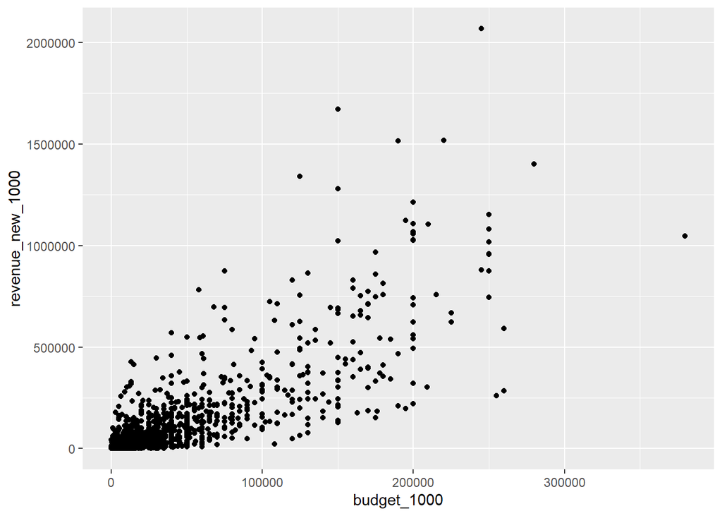

```r
ggplot(metadata_new_numeric, aes(x = budget_1000, y = revenue_new_1000)) +
  geom_point()
```

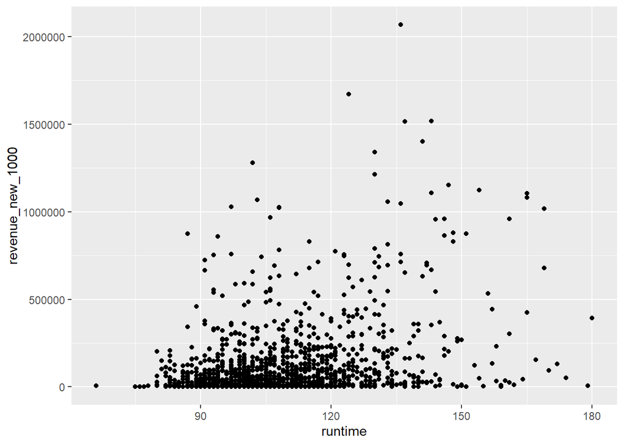

```r
ggplot(metadata_new_numeric, aes(x = runtime, y = revenue_new_1000)) +
  geom_point()
```

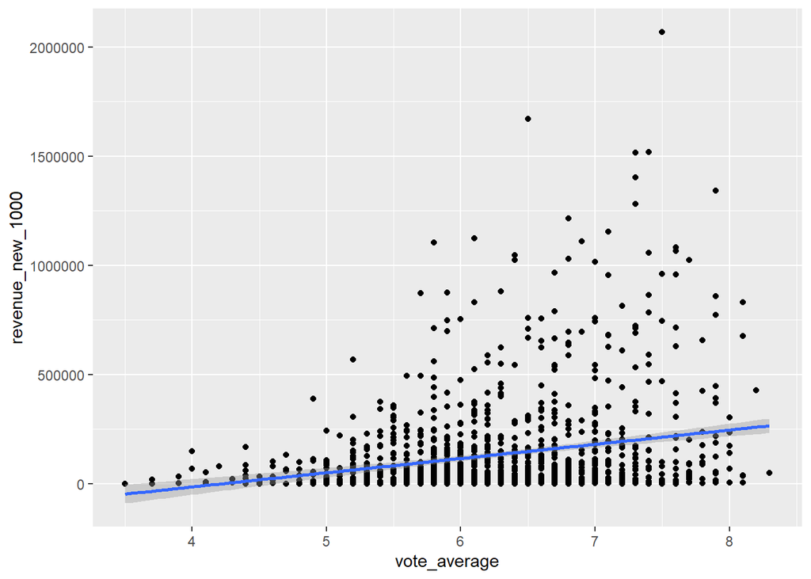

```r
ggplot(metadata_new_numeric, aes(x = vote_average, y = revenue_new_1000)) +
  geom_point() +
  geom_smooth(method = "lm")
```

#nem lineáris kapcsolat (?)

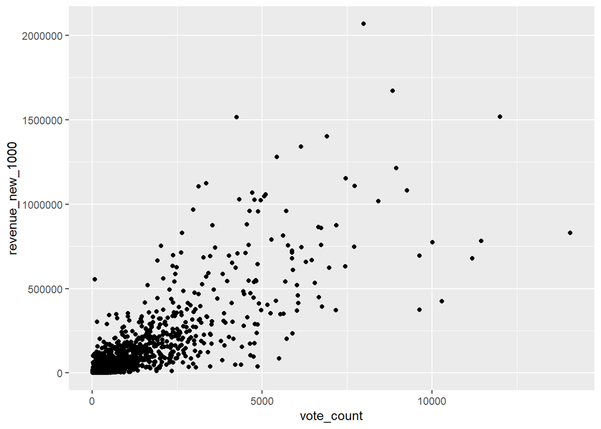

```r
ggplot(metadata_new_numeric, aes(x = vote_count, y = revenue_new_1000)) +
  geom_point()
```

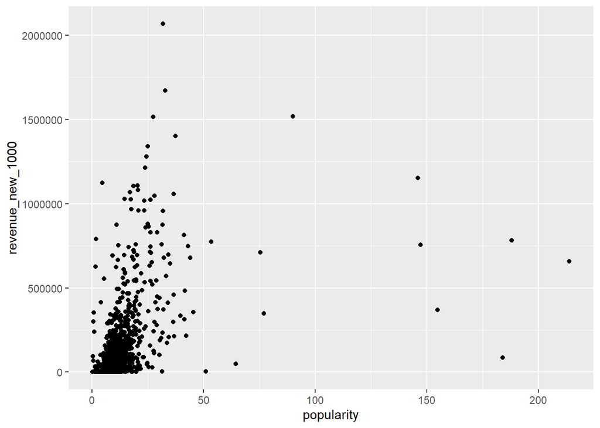

```r
ggplot(metadata_new_numeric, aes(x = popularity, y = revenue_new_1000)) +
  geom_point()
```

#A nagyon népszerű filmek esetében alacsony a bevétel? Ez lehet, hogy adathiba.

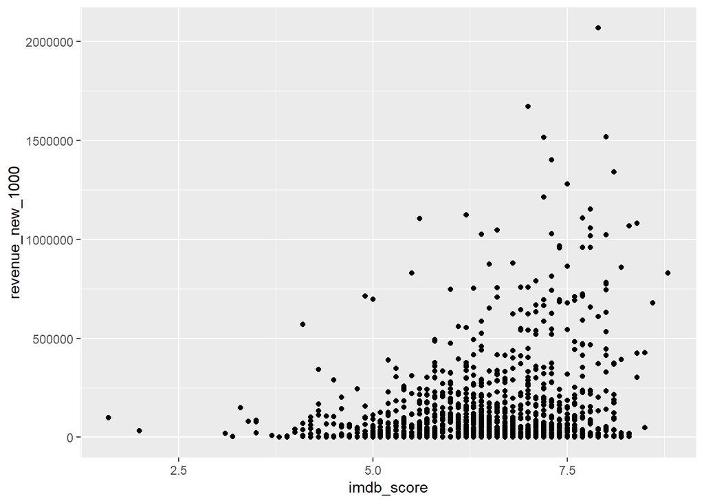

```r
ggplot(metadata_new_numeric, aes(x = imdb_score, y = revenue_new_1000)) +
  geom_point()
```

```r
summary(metadata_new_numeric)
```

```
##    popularity          runtime       vote_average     vote_count
##  Min.   :  0.1101   Min.   : 66.0   Min.   :3.500   Min.   :   11.0
##  1st Qu.:  6.8903   1st Qu.: 97.0   1st Qu.:5.700   1st Qu.:  216.8
##  Median :  9.5805   Median :106.5   Median :6.300   Median :  618.0
##  Mean   : 11.9848   Mean   :109.4   Mean   :6.258   Mean   : 1270.6
##  3rd Qu.: 13.4570   3rd Qu.:119.0   3rd Qu.:6.800   3rd Qu.: 1621.8
##  Max.   :213.8499   Max.   :180.0   Max.   :8.300   Max.   :14075.0
##  language_dummy      dummy_en        imdb_score    revenue_new_1000
##  Min.   :0.0000   Min.   :0.0000   Min.   :1.600   Min.   :      0.7
##  1st Qu.:0.0000   1st Qu.:1.0000   1st Qu.:5.900   1st Qu.:   9488.2
##  Median :0.0000   Median :1.0000   Median :6.500   Median :  48918.2
##  Mean   :0.2532   Mean   :0.9034   Mean   :6.435   Mean   : 132496.4
##  3rd Qu.:1.0000   3rd Qu.:1.0000   3rd Qu.:7.100   3rd Qu.: 151285.4
##  Max.   :1.0000   Max.   :1.0000   Max.   :8.800   Max.   :2068223.6
##   budget_1000
##  Min.   :     0
##  1st Qu.:  8790
##  Median : 21000
##  Mean   : 42200
##  3rd Qu.: 50000
##  Max.   :380000
```

```r
corr <- metadata_new %>%
  keep(is.numeric) %>%
  cor(use = "na.or.complete")

corr
```

```
##                       budget  popularity     revenue     runtime
## budget            1.00000000  0.33774136  0.79589508  0.34173292
## popularity        0.33774136  1.00000000  0.43071869  0.15608158
## revenue           0.79589508  0.43071869  1.00000000  0.31551818
## runtime           0.34173292  0.15608158  0.31551818  1.00000000
## vote_average      0.08173065  0.21557253  0.24178177  0.41264745
## vote_count        0.66324896  0.55679597  0.78209736  0.37019721
## language_dummy   -0.03328317 -0.02581608 -0.05790004  0.11743080
## year              0.01225070  0.16282301  0.04318814  0.11382263
## month            -0.01529184  0.04998967  0.01036664  0.17149697
## day               0.07921105  0.04317889  0.07086162  0.03113345
## dummy_en          0.18069703  0.11435211  0.13584835 -0.16845458
## revenue_new       0.79622275  0.43183097  0.99507729  0.31281020
## imdb_score        0.13088306  0.21330385  0.24547603  0.42201042
## revenue_new_1000  0.79622275  0.43183097  0.99507729  0.31281020
## budget_1000       1.00000000  0.33774136  0.79589508  0.34173292
##                  vote_average  vote_count language_dummy        year
## budget             0.08173065  0.66324896    -0.03328317  0.01225070
## popularity         0.21557253  0.55679597    -0.02581608  0.16282301
## revenue            0.24178177  0.78209736    -0.05790004  0.04318814
## runtime            0.41264745  0.37019721     0.11743080  0.11382263
## vote_average       1.00000000  0.39672769     0.08793430  0.09114698
## vote_count         0.39672769  1.00000000    -0.02233094  0.07661812
## language_dummy     0.08793430 -0.02233094     1.00000000 -0.06239256
## year               0.09114698  0.07661812    -0.06239256  1.00000000
## month              0.18601097  0.02370343     0.03142367  0.01679789
## day                0.04512855  0.08368566     0.02187409  0.03274402
## dummy_en          -0.20620260  0.16519726    -0.19791065 -0.01944675
## revenue_new        0.24424172  0.78999545    -0.05179506  0.03898798
## imdb_score         0.91990228  0.41897655     0.11455060  0.05373513
## revenue_new_1000   0.24424172  0.78999545    -0.05179506  0.03898798
## budget_1000        0.08173065  0.66324896    -0.03328317  0.01225070
##                         month         day    dummy_en  revenue_new
## budget           -0.015291836  0.07921105  0.18069703  0.796222748
## popularity        0.049989671  0.04317889  0.11435211  0.431830968
## revenue           0.010366643  0.07086162  0.13584835  0.995077286
## runtime           0.171496966  0.03113345 -0.16845458  0.312810198
## vote_average      0.186010967  0.04512855 -0.20620260  0.244241719
## vote_count        0.023703429  0.08368566  0.16519726  0.789995452
## language_dummy    0.031423670  0.02187409 -0.19791065 -0.051795059
```

[output cut: 9 more lines]

```
## budget            0.13088306      0.796222748  1.00000000
## popularity        0.21330385      0.431830968  0.33774136
## revenue           0.24547603      0.995077286  0.79589508
## runtime           0.42201042      0.312810198  0.34173292
## vote_average      0.91990228      0.244241719  0.08173065
## vote_count        0.41897655      0.789995452  0.66324896
## language_dummy    0.11455060     -0.051795059 -0.03328317
## year              0.05373513      0.038987985  0.01225070
## month             0.17088929      0.009002761 -0.01529184
## day               0.04792967      0.069639850  0.07921105
## dummy_en         -0.18049341      0.138503783  0.18069703
## revenue_new       0.24816009      1.000000000  0.79622275
## imdb_score        1.00000000      0.248160092  0.13088306
## revenue_new_1000  0.24816009      1.000000000  0.79622275
## budget_1000       0.13088306      0.796222748  1.00000000
```

```r
corr[corr > abs(0.9) & corr!= abs(1)]
```

```
## [1] 0.9950773 0.9950773 0.9199023 0.9950773 0.9199023 0.9950773
```

```r
fold <- 5
n <- nrow(metadata_new_numeric)
set.seed(65445)
split <- split(sample(1:n), 1:fold) #5 csoportba rendezi az adatok sorszámait
test_ <- unlist(split[5])
train_ <- unlist(split[c(1:4)])
test <- metadata_new_numeric[test_]
train <- metadata_new_numeric[train_]
```

#Teljes adaton:

```r
reg <- lm(revenue_new_1000 ~ .,
          data = metadata_new_numeric)

summary(reg)
```

```
##
## Call:
## lm(formula = revenue_new_1000 ~ ., data = metadata_new_numeric)
##
## Residuals:
##     Min      1Q  Median      3Q     Max
## -485683  -35612    -336   28161 1098345
##
## Coefficients:
##                    Estimate   Std. Error t value             Pr(>|t|)
## (Intercept)      7484.74111  34261.08297   0.218              0.82711
## popularity         83.15918    270.42604   0.308              0.75851
## runtime          -543.03762    210.89806  -2.575              0.01014 *
## vote_average    45222.24692   9137.28979   4.949          0.000000848 ***
## vote_count         61.88518      3.04097  20.350 < 0.0000000000000002 ***
## language_dummy -11939.41609   7169.11874  -1.665              0.09609 .
## dummy_en       -31389.74348  11220.39764  -2.798              0.00523 **
## imdb_score     -36785.36138   7894.80473  -4.659          0.000003512 ***
## budget_1000         2.12978      0.08262  25.778 < 0.0000000000000002 ***
## ---
## Signif. codes:  0 '***' 0.001 '**' 0.01 '*' 0.05 '.' 0.1 ' ' 1
##
## Residual standard error: 107400 on 1243 degrees of freedom
## Multiple R-squared:  0.7682, Adjusted R-squared:  0.7667
## F-statistic: 514.9 on 8 and 1243 DF,  p-value: < 0.00000000000000022
```

```r
residuals <- data.table(residuals = reg$residuals, fitted = reg$fitted.values, metadata)
```

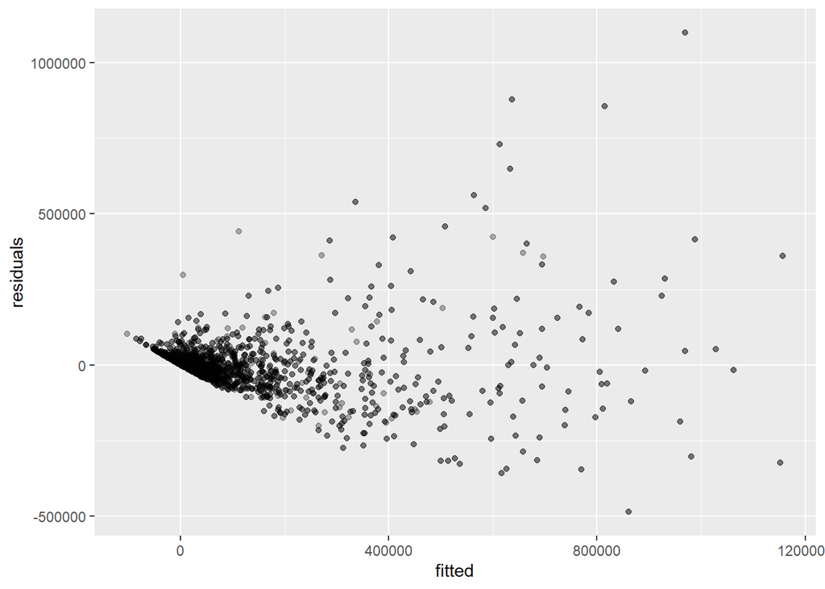

```r
ggplot(residuals, aes(fitted, residuals)) +
  geom_point(alpha = .3)
```

#“Kis” értékek esetében felülbecsli, a szórás nő az illesztett értékekkel.

```r
form_1 <- as.formula(revenue_new_1000 ~ .)
reg_1 <- lm(form_1,
          data = train)

MSE_1_train <- mean((reg_1$fitted.values - train[, revenue_new_1000])^2)

p <- predict(reg_1, test)
MSE_1_test = mean((p - test[, revenue_new_1000])^2)

#summary(reg_1)
```

```r
form_2 <- as.formula(revenue_new_1000 ~ . + log(runtime))
reg_2 <- lm(form_2,
          data = train)

MSE_2_train <- mean((reg_2$fitted.values - train[, revenue_new_1000])^2)

p <- predict(reg_2, test)
MSE_2_test = mean((p - test[, revenue_new_1000])^2)

#summary(reg_2)
```

```r
form_3 <- as.formula(revenue_new_1000 ~ . + log(runtime) + log(popularity))
reg_3 <- lm(form_3,
          data = train)

MSE_3_train <- mean((reg_3$fitted.values - train[, revenue_new_1000])^2)

p <- predict(reg_3, test)
MSE_3_test = mean((p - test[, revenue_new_1000])^2)

#summary(reg_3)
```

```r
form_4 <- as.formula(revenue_new_1000 ~ . + log(runtime) + log(popularity) + I(popularity^2))
reg_4 <- lm(form_4,
          data = train)

MSE_4_train <- mean((reg_4$fitted.values - train[, revenue_new_1000])^2)

p <- predict(reg_4, test)
MSE_4_test = mean((p - test[, revenue_new_1000])^2)

#summary(reg_4)
```

```r
form_5 <- as.formula(revenue_new_1000 ~ . + log(runtime) + log(popularity) + I(popularity^2) + log(vote_average))
reg_5 <- lm(form_5,
          data = train)

MSE_5_train <- mean((reg_5$fitted.values - train[, revenue_new_1000])^2)

p <- predict(reg_5, test)
MSE_5_test = mean((p - test[, revenue_new_1000])^2)

#summary(reg_5)
```

#Összefoglalás:

```r
train_test <- data.table("model" = c(1:5),
            `train MSE` = c(MSE_1_train, MSE_2_train, MSE_3_train, MSE_4_train, MSE_5_train),
           `test MSE` = c(MSE_1_test, MSE_2_test, MSE_3_test, MSE_4_test, MSE_5_test))
train_test
```

```
##    model   train MSE    test MSE
## 1:     1 10523961039 15483235712
## 2:     2 10495194030 15345245426
## 3:     3 10458272983 15442643495
## 4:     4 10361352561 15356865036
## 5:     5 10348042813 15432322459
```

#cross validation

```r
train_control <- trainControl(method = "cv", number = 5)
```

```r
set.seed(1)
model_1 <- train(form_1,
               data = metadata_new_numeric,
               trControl = train_control,
               method = "lm")
model_1$resample
```

```
##        RMSE  Rsquared      MAE Resample
## 1 101865.15 0.7808140 57199.06    Fold1
## 2 114046.74 0.7691196 62000.54    Fold2
## 3 118987.88 0.7428225 62913.15    Fold3
## 4  87128.31 0.8285825 57495.82    Fold4
## 5 118824.37 0.7261222 62402.44    Fold5
```

```r
cv_MSE_1 <- model_1$results$RMSE**2
```

```r
set.seed(2)
model_2 <- train(form_2,
               data = metadata_new_numeric,
               trControl = train_control,
               method = "lm")
model_2$resample
```

```
##        RMSE  Rsquared      MAE Resample
## 1 102146.42 0.8206728 62894.70    Fold1
## 2  88377.68 0.7300177 57506.55    Fold2
## 3 123940.07 0.6971025 63776.75    Fold3
## 4 123424.50 0.7239270 61290.12    Fold4
## 5  99351.50 0.8245008 57101.53    Fold5
```

```r
cv_MSE_2 <- model_2$results$RMSE**2
```

```r
set.seed(3)
model_3 <- train(form_3,
               data = metadata_new_numeric,
               trControl = train_control,
               method = "lm")
model_3$resample
```

```
##        RMSE  Rsquared      MAE Resample
## 1 111984.75 0.7874723 63999.42    Fold1
## 2 129915.08 0.6284070 64301.66    Fold2
## 3 115195.08 0.7551946 62711.40    Fold3
## 4  84392.31 0.7907659 53683.30    Fold4
## 5  98373.73 0.8418923 58161.18    Fold5
```

```r
cv_MSE_3 <- model_3$results$RMSE**2
```

```r
set.seed(4)
model_4 <- train(form_4,
               data = metadata_new_numeric,
               trControl = train_control,
               method = "lm")
model_4$resample
```

```
##        RMSE  Rsquared      MAE Resample
## 1 108002.15 0.8125896 59618.53    Fold1
## 2 122257.82 0.7301143 60083.90    Fold2
## 3  90906.18 0.8045213 58572.45    Fold3
## 4  97654.35 0.8021975 58934.80    Fold4
## 5 118028.57 0.6752330 64484.75    Fold5
```

```r
cv_MSE_4 <- model_4$results$RMSE**2
```

```r
set.seed(5)
model_5 <- train(form_5,
               data = metadata_new_numeric,
               trControl = train_control,
               method = "lm")
model_5$resample
```

```
##        RMSE  Rsquared      MAE Resample
## 1  94498.22 0.8313848 59918.29    Fold1
## 2  94520.02 0.7692582 57596.91    Fold2
## 3 127818.76 0.7359510 64391.46    Fold3
## 4 104103.36 0.7791285 57347.20    Fold4
## 5 112508.65 0.7261693 61540.23    Fold5
```

```r
cv_MSE_5 <- model_5$results$RMSE**2
```

#Összefoglalás:

```r
data.table(train_test, `cv MSE` = c(cv_MSE_1, cv_MSE_2, cv_MSE_3,
                                    cv_MSE_4, cv_MSE_5))
```

```
##    model   train MSE    test MSE      cv MSE
## 1:     1 10523961039 15483235712 11700854939
## 2:     2 10495194030 15345245426 11545080168
## 3:     3 10458272983 15442643495 11657993569
## 4:     4 10361352561 15356865036 11528276524
## 5:     5 10348042813 15432322459 11382713712
```

#Adatok gyűjtése:

```r
#Scraping
#n = nrow(metadata)
#url_vector <- str_c("https://www.imdb.com/title/", metadata$imdb_id)

#revenue <- c()
#for (i in url_vector) {
#    page <- read_html(i)
#    movie_gross_15 <- html_node(page,'#titleDetails :nth-child(15)')
#    movie_gross_14 <- html_node(page,'#titleDetails :nth-child(14)')
#    movie_gross_13 <- html_node(page,'#titleDetails :nth-child(13)')
#    data_15 <- html_text(movie_gross_15)
#    data_14 <- html_text(movie_gross_14)
#    data_13 <- html_text(movie_gross_13)

#      #15. sor
#      if (is.na(data_15) == FALSE) {
#      gross <-gsub("\n","",
#                    gsub(",", "",
#                    substring(data_15, 31, 44)))

#      #tényleg a kumulatív bevétel
#      if (substring(data_15, 2, 11) == "Cumulative") {
#        revenue_n <- as.numeric(gross)
#        n = which(url_vector == i)
#        revenue[n] = revenue_n

#        }} else if (is.na(data_14) == FALSE) {
#            gross <-gsub("\n","",
#                    gsub(",", "",
#                    substring(data_14, 31, 44)))
#                revenue_n <- as.numeric(gross)

#            #tényleg a kumulatív bevétel
#            if (substring(data_14, 2, 11) == "Cumulative") {
#            n = which(url_vector == i)
#            revenue[n] = revenue_n

#            }} else if (is.na(data_13) == FALSE) {
#            gross <-gsub("\n","",
#                    gsub(",", "",
#                    substring(data_13, 31, 44)))
#                revenue_n <- as.numeric(gross)

#            #tényleg a kumulatív bevétel
#            if (substring(data_13, 2, 11) == "Cumulative") {
#            n = which(url_vector == i)
#            revenue[n] = revenue_n
#  }}}

#revenue_new = revenue


#url_vector_new <- str_c("https://www.imdb.com/title/", metadata_new$imdb_id)
#imdb_score = c()
#for (i in url_vector_new) {
#  page <- read_html(i)
#  rating_data <- html_nodes(page, "strong span")
#  rating_text <- html_text(rating_data)
#  rating <- as.numeric(rating_text)
#  n = which(url_vector_new == i)
#  imdb_score[n] <- rating
#}

#metadata_new <- data.table(metadata, revenue_new)
#metadata_new <- metadata_new[is.na(revenue_new) == FALSE]

#metadata_new <- data.table(metadata_new, imdb_score)

#score_revenue <- data.table(imdb_score, metadata_new$revenue_new)
#write.csv(score_revenue, "score_revenue.csv")
```